# 时序第7次作业

苏锦华 2017201620

# 第一题

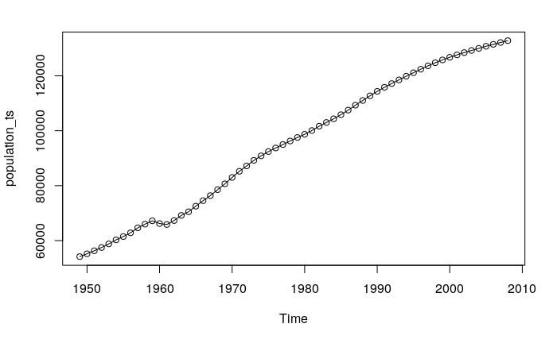

```r
table =read.table('../习题数据/习题4.5数据.txt',fill =T)
population = c()
for(i in 1:8){
  for(j in 1:8){
    if (i != 8 || j <= 4){
      population = c(population,table[i,j])
    }
  }
}
population_ts = ts(population,start=1949)
plot(population_ts,type="o")
```

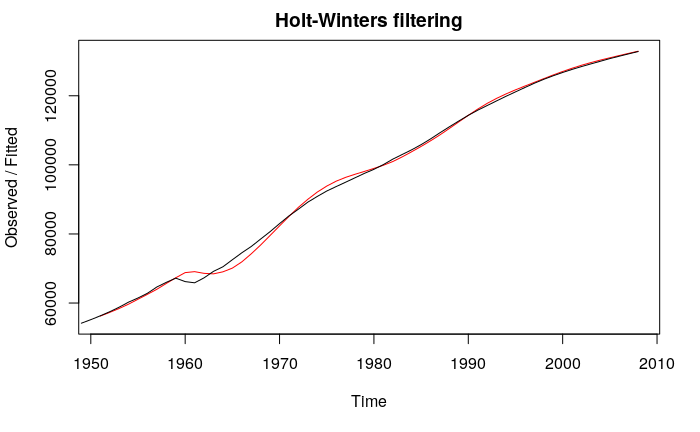

```r
library(forecast)
Holfit <- HoltWinters(population_ts,alpha=0.3,beta=0.6,gamma=F)
fore <- forecast(Holfit, h=5)
plot(Holfit)
```

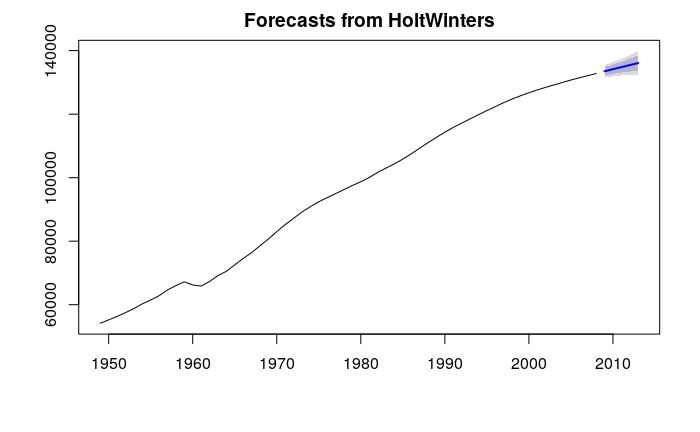

```r
plot(fore)
```

```r
Holfit
```

```
Holt-Winters exponential smoothing with trend and without seasonal component.

Call:
HoltWinters(x = population_ts, alpha = 0.3, beta = 0.6, gamma = F)

Smoothing parameters:
 alpha: 0.3
 beta : 0.6
 gamma: FALSE

Coefficients:
         [,1]
a 132866.4328
b    646.4791
```

```r
fore
```

|  | Point Forecast | Lo 80 | Hi 80 | Lo 95 | Hi 95 |
| --- | --- | --- | --- | --- | --- |
| 2009 | 133512.9 | 132191.6 | 134834.2 | 131492.1 | 135533.7 |
| 2010 | 134159.4 | 132693.8 | 135625.0 | 131917.9 | 136400.9 |
| 2011 | 134805.9 | 133100.4 | 136511.3 | 132197.6 | 137414.1 |
| 2012 | 135452.3 | 133417.5 | 137487.2 | 132340.4 | 138564.3 |
| 2013 | 136098.8 | 133658.2 | 138539.5 | 132366.2 | 139831.5 |

准备拟合arima模型，先做一阶差分，查看自相关系数图，发现2阶截尾，而偏自相关系数图1阶截尾，所以模型应该是arima（1,1,2）,白噪音检验均拒绝白噪音的原假设。

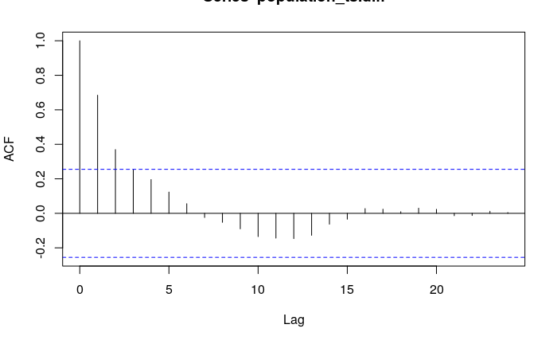

```r
population_ts.diff = diff(population_ts)
acf(population_ts.diff,lag=24)
```

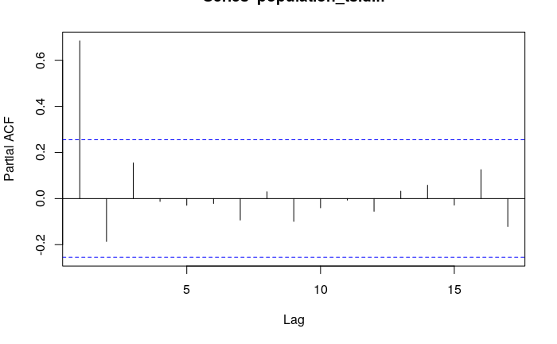

```r
pacf(population_ts.diff)
```

```r
for(i in 1:4) print(Box.test(population_ts.diff,lag=6*i))
```

```
    Box-Pierce test

data:  population_ts.diff
X-squared = 42.785, df = 6, p-value = 1.287e-07


    Box-Pierce test

data:  population_ts.diff
X-squared = 47.015, df = 12, p-value = 4.634e-06


    Box-Pierce test

data:  population_ts.diff
X-squared = 48.361, df = 18, p-value = 0.000133


    Box-Pierce test

data:  population_ts.diff
X-squared = 48.476, df = 24, p-value = 0.002203
```

使用自动定阶，发现arima（1,1,1）更合适。

```r
library(zoo)
library(forecast)
auto.arima(population_ts)
```

```
Series: population_ts
ARIMA(1,1,1) with drift

Coefficients:
         ar1     ma1      drift
      0.5175  0.3487  1311.3632
s.e.  0.1529  0.1706   138.7974

sigma^2 estimated as 159553:  log likelihood=-435.97
AIC=879.94   AICc=880.68   BIC=888.25
```

拟合模型后将残差序列进行白噪音检验，发现残差序列为白噪音，时序建模结束。

```r
population_ts.fit <- arima(population_ts, order = c(1,1,1), method = "ML")
population_ts.fit
```

```
Call:
arima(x = population_ts, order = c(1, 1, 1), method = "ML")

Coefficients:
         ar1     ma1
      0.9411  0.0658
s.e.  0.0423  0.2129

sigma^2 estimated as 182635:  log likelihood = -442.26,  aic = 890.53
```

```r
for(i in 1:2) print(Box.test(population_ts.fit$residual, lag= 6*i))
```

```
    Box-Pierce test

data:  population_ts.fit$residual
X-squared = 6.235, df = 6, p-value = 0.3974


    Box-Pierce test

data:  population_ts.fit$residual
X-squared = 8.5267, df = 12, p-value = 0.7427
```

```r
population_ts.fore <- forecast(population_ts.fit, h=5)
population_ts.fore
```

|  | Point Forecast | Lo 80 | Hi 80 | Lo 95 | Hi 95 |
| --- | --- | --- | --- | --- | --- |
| 2009 | 133437.3 | 132889.6 | 133985.0 | 132599.7 | 134274.9 |
| 2010 | 134035.2 | 132807.2 | 135263.3 | 132157.1 | 135913.3 |
| 2011 | 134597.9 | 132566.5 | 136629.2 | 131491.2 | 137704.6 |
| 2012 | 135127.4 | 132200.9 | 138053.8 | 130651.8 | 139602.9 |
| 2013 | 135625.7 | 131733.5 | 139517.8 | 129673.1 | 141578.2 |

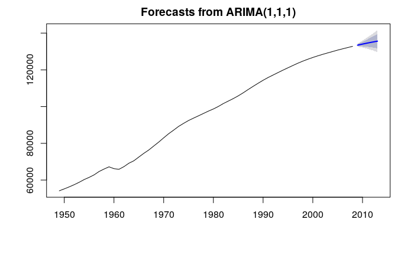

```r
plot(population_ts.fore)
```

# 第二题

I use covid-19 data published by wangyi. There are fields like confirm, suspect, heal and etc. Since the confirm number is measured by different methods, I use suspect series to fit my arima model and make some predictions.

```r
library(zoo)
table =read.csv('covid.csv')
df = as.data.frame(table)
df
```

| X | confirm | suspect | heal | dead | severe | storeConfirm | input |
| --- | --- | --- | --- | --- | --- | --- | --- |
| 2020-01-20 | 291 | 27 | 25 | 6 | 0 | NA | NA |
| 2020-01-21 | 149 | 26 | -25 | 3 | 0 | NA | NA |
| 2020-01-22 | 131 | 257 | 28 | 8 | 0 | NA | NA |
| 2020-01-23 | 259 | 680 | 6 | 8 | 0 | NA | NA |
| 2020-01-24 | 444 | 1118 | 4 | 16 | 0 | NA | NA |
| 2020-01-25 | 688 | 1309 | 11 | 15 | 0 | NA | NA |
| 2020-01-26 | 769 | 3806 | 2 | 24 | 0 | NA | NA |
| 2020-01-27 | 1771 | 2077 | 9 | 26 | 0 | NA | NA |
| 2020-01-28 | 1459 | 3248 | 43 | 26 | 0 | NA | NA |
| 2020-01-29 | 1737 | 4148 | 21 | 38 | 0 | NA | NA |

[output cut: 109 more lines]

I use 2020-1-20 ~ 2020-2-13 suspect number as train data, and 2020-2-14~2020-2-28 for testing model property.

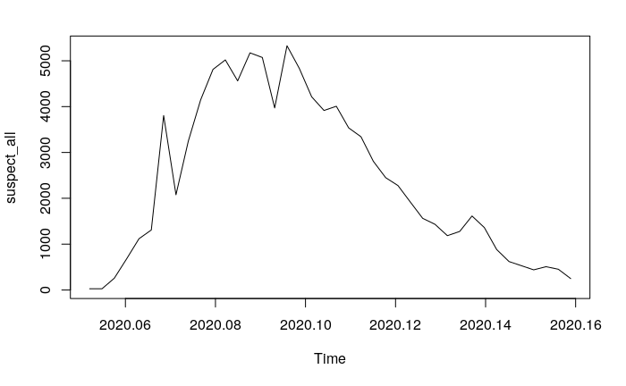

```r
suspect_all = ts(df$suspect[1:40],start=c(2020,20),frequency=365)
suspect = ts(suspect_all[1:25],start=c(2020,20),frequency=365)
plot(suspect_all)
```

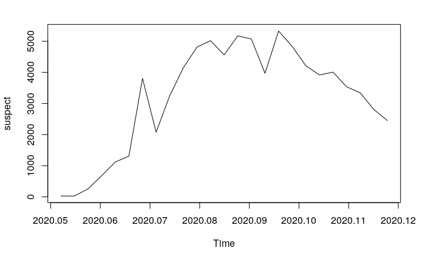

```r
plot(suspect)
```

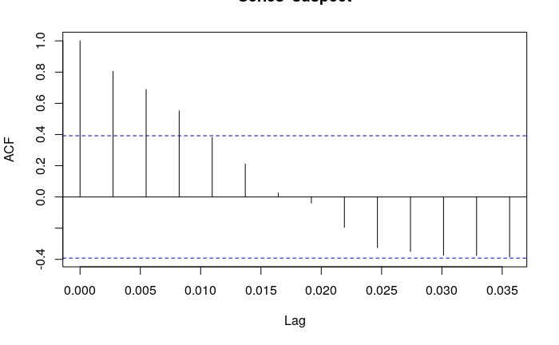

```r
library(fUnitRoots)
acf(suspect)
```

```r
for (i in 1:2) print(adfTest(suspect,lag=i,type="c"))
```

```
Title:
 Augmented Dickey-Fuller Test

Test Results:
  PARAMETER:
    Lag Order: 1
  STATISTIC:
    Dickey-Fuller: -2.0862
  P VALUE:
    0.2925

Description:
 Tue May 19 09:21:14 2020 by user:


Title:
 Augmented Dickey-Fuller Test

Test Results:
  PARAMETER:
    Lag Order: 2
  STATISTIC:
    Dickey-Fuller: -2.1971
  P VALUE:
    0.2532

Description:
 Tue May 19 09:21:14 2020 by user:
```

```r
for(i in 1:2) print(Box.test(suspect,lag=6*i))
```

```
    Box-Pierce test

data:  suspect
X-squared = 40.432, df = 6, p-value = 3.746e-07


    Box-Pierce test

data:  suspect
X-squared = 54.138, df = 12, p-value = 2.582e-07
```

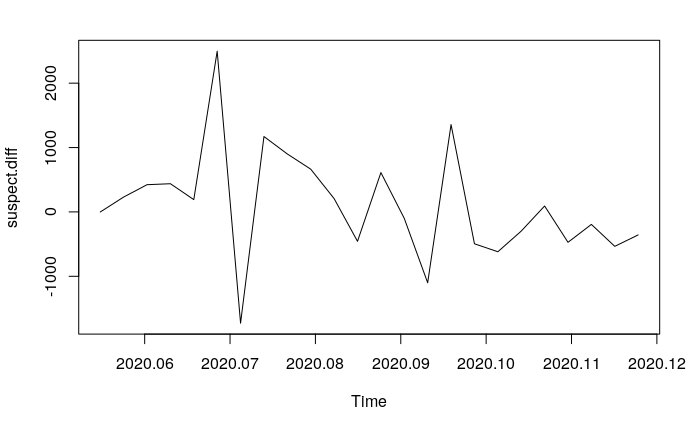

```r
suspect.diff = diff(suspect)
plot(suspect.diff)
```

```r
for (i in 1:2) print(adfTest(suspect.diff,lag=i,type="c"))
```

```
Title:
 Augmented Dickey-Fuller Test

Test Results:
  PARAMETER:
    Lag Order: 1
  STATISTIC:
    Dickey-Fuller: -3.3927
  P VALUE:
    0.02276

Description:
 Tue May 19 09:21:14 2020 by user:


Title:
 Augmented Dickey-Fuller Test

Test Results:
  PARAMETER:
    Lag Order: 2
  STATISTIC:
    Dickey-Fuller: -1.6879
  P VALUE:
    0.4335

Description:
 Tue May 19 09:21:14 2020 by user:
```

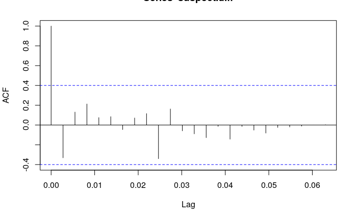

```r
acf(suspect.diff,lag=24)
```

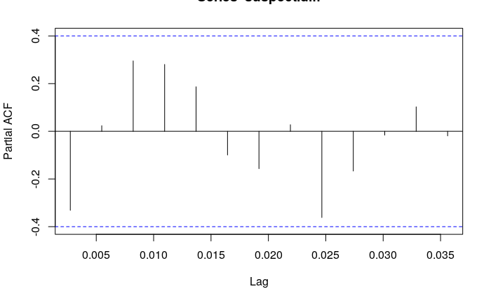

```r
pacf(suspect.diff)
```

I use auto arima function to grid search a best arima model. It finally returns a arima(1,2,1), and both ar1 and ma1 are significant.

```r
library(zoo)
library(forecast)
auto.arima(suspect)
```

```
Series: suspect
ARIMA(1,2,1)

Coefficients:
          ar1      ma1
      -0.4767  -0.7593
s.e.   0.1851   0.1232

sigma^2 estimated as 681574:  log likelihood=-186.93
AIC=379.85   AICc=381.12   BIC=383.26
```

I fit this arima(1,2,1) and then test whether the residual is a white noise series. Results show that it does.

```r
suspect.fit <- arima(suspect, order = c(1,2,1), method = "ML")
suspect.fit
```

```
Call:
arima(x = suspect, order = c(1, 2, 1), method = "ML")

Coefficients:
          ar1      ma1
      -0.4769  -0.7596
s.e.   0.1851   0.1230

sigma^2 estimated as 622265:  log likelihood = -186.93,  aic = 379.85
```

```r
for(i in 1:2) print(Box.test(suspect.fit$residual, lag= 6*i))
```

```
    Box-Pierce test

data:  suspect.fit$residual
X-squared = 4.4454, df = 6, p-value = 0.6166


    Box-Pierce test

data:  suspect.fit$residual
X-squared = 10.185, df = 12, p-value = 0.5998
```

I use airma to predict the suspect number between 2020-2-14~2020-2-28. It seems to fit the trend well but care little about the random effect. In a word, it can predict in a short time(in this example, it work fairly good in five days), and give a trend estimate in a long time.

```r
suspect.fore <- forecast(suspect.fit, h=15)
suspect.fore
```

|  | Point Forecast | Lo 80 | Hi 80 | Lo 95 | Hi 95 |
| --- | --- | --- | --- | --- | --- |
| 2020.1205 | 2205.8029 | 1194.86610 | 3216.740 | 659.70850 | 3751.897 |
| 2020.1233 | 1907.8090 | 635.90651 | 3179.712 | -37.39803 | 3853.016 |
| 2020.1260 | 1635.4714 | -65.16207 | 3336.105 | -965.42302 | 4236.366 |
| 2020.1288 | 1350.8980 | -731.43578 | 3433.232 | -1833.75671 | 4535.553 |
| 2020.1315 | 1072.1600 | -1442.63138 | 3586.951 | -2773.88151 | 4918.201 |
| 2020.1342 | 790.6390 | -2165.37757 | 3746.656 | -3730.19822 | 5311.476 |
| 2020.1370 | 510.4453 | -2913.67687 | 3934.567 | -4726.29763 | 5747.188 |
| 2020.1397 | 229.6186 | -3680.50533 | 4139.742 | -5750.39988 | 6209.637 |
| 2020.1425 | -50.9063 | -4468.06084 | 4366.248 | -6806.36120 | 6704.549 |
| 2020.1452 | -331.5751 | -5274.44614 | 4611.296 | -7891.04401 | 7227.894 |

[output cut: 5 more lines]

```r
plot(suspect.fore)
par(new=TRUE)
```

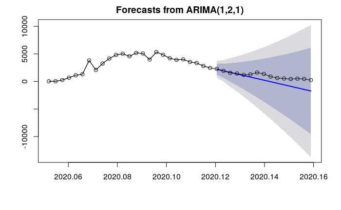

```r
points(suspect_all,type='o')
```

```r
suspect.fore
```

|  | Point Forecast | Lo 80 | Hi 80 | Lo 95 | Hi 95 |
| --- | --- | --- | --- | --- | --- |
| 2020.1205 | 2205.8029 | 1194.86610 | 3216.740 | 659.70850 | 3751.897 |
| 2020.1233 | 1907.8090 | 635.90651 | 3179.712 | -37.39803 | 3853.016 |
| 2020.1260 | 1635.4714 | -65.16207 | 3336.105 | -965.42302 | 4236.366 |
| 2020.1288 | 1350.8980 | -731.43578 | 3433.232 | -1833.75671 | 4535.553 |
| 2020.1315 | 1072.1600 | -1442.63138 | 3586.951 | -2773.88151 | 4918.201 |
| 2020.1342 | 790.6390 | -2165.37757 | 3746.656 | -3730.19822 | 5311.476 |
| 2020.1370 | 510.4453 | -2913.67687 | 3934.567 | -4726.29763 | 5747.188 |
| 2020.1397 | 229.6186 | -3680.50533 | 4139.742 | -5750.39988 | 6209.637 |
| 2020.1425 | -50.9063 | -4468.06084 | 4366.248 | -6806.36120 | 6704.549 |
| 2020.1452 | -331.5751 | -5274.44614 | 4611.296 | -7891.04401 | 7227.894 |

[output cut: 5 more lines]